# BALANCE OF PAYMENT ANALYSIS

# Introduction

# Problem Statement

## CURRENT ACCOUNT ANALYSIS

What is the current account balance and what components contribute to it (e.g., trade balance, income, transfers)?

# Data

# Dataset characteristics

```r
df_filtered <-read.csv('BalanceOfPayment.csv',header = TRUE)
```

# DATA PRE-PROCESSING

## CURRENT ACCOUNT BALANCE

```r
head(df_filtered)
```

```
##   X                      Country Code
## 1 1 Afghanistan, Islamic Rep. of  512
## 2 2 Afghanistan, Islamic Rep. of  512
## 3 3 Afghanistan, Islamic Rep. of  512
## 4 4 Afghanistan, Islamic Rep. of  512
## 5 5 Afghanistan, Islamic Rep. of  512
## 6 6 Afghanistan, Islamic Rep. of  512
##                                                                                    Indicator
## 1                                                    Capital Account, Total, Net, US Dollars
## 2 Net Lending (+) / Net Borrowing (-) (Balance from Current and Capital Account), US Dollars
## 3                                                 Capital Account, Total, Credit, US Dollars
## 4                                                  Capital Account, Total, Debit, US Dollars
## 5                                    Current Account, Goods and Services, Credit, US Dollars
## 6                                     Current Account, Goods and Services, Debit, US Dollars
##           Icode       X2015       X2016       X2017       X2018       X2019
## 1    BK_BP6_USD  1318093915  1292837234  1305692895  1314405726  1193939877
## 2  BACK_BP6_USD -2874722508 -1415625702 -2249205048 -2582431878 -2597995379
## 3 BK_CD_BP6_USD  1318093915  1292837234  1305692895  1314405726  1193939877
## 4 BK_DB_BP6_USD           0           0           0           0           0
## 5  BXGS_BP6_USD  1417300546  1136013206  1152896050  1609472021  1515758749
## 6  BMGS_BP6_USD  8462264707  7327477074  7956456168  7987638963  7370819805
##         X2020
## 1   753119495
## 2 -2383613858
## 3   753119495
## 4           0
## 5  1476305961
## 6  6982852963
```

```r
summary(df_filtered)
```

```
##        X          Country               Code        Indicator
##  Min.   :   1   Length:4959        Min.   :111.0   Length:4959
##  1st Qu.:1688   Class :character   1st Qu.:288.0   Class :character
##  Median :3180   Mode  :character   Median :542.0   Mode  :character
##  Mean   :3202                      Mean   :540.5
##  3rd Qu.:4786                      3rd Qu.:746.0
##  Max.   :6327                      Max.   :968.0
##     Icode               X2015                X2016
##  Length:4959        Min.   :-4.164e+11   Min.   :-4.436e+11
##  Class :character   1st Qu.: 0.000e+00   1st Qu.: 0.000e+00
##  Mode  :character   Median : 6.259e+07   Median : 6.547e+07
##                     Mean   : 1.425e+10   Mean   : 1.325e+10
##                     3rd Qu.: 1.211e+09   3rd Qu.: 1.187e+09
##                     Max.   : 3.235e+12   Max.   : 3.245e+12
##      X2017                X2018                X2019
##  Min.   :-3.552e+11   Min.   :-6.201e+11   Min.   :-4.482e+11
##  1st Qu.: 0.000e+00   1st Qu.: 0.000e+00   1st Qu.: 0.000e+00
##  Median : 8.305e+07   Median : 6.898e+07   Median : 9.657e+07
##  Mean   : 1.565e+10   Mean   : 1.410e+10   Mean   : 1.557e+10
##  3rd Qu.: 1.485e+09   3rd Qu.: 1.284e+09   3rd Qu.: 1.603e+09
##  Max.   : 3.570e+12   Max.   : 3.873e+12   Max.   : 3.815e+12
##      X2020
##  Min.   :-6.028e+11
##  1st Qu.: 0.000e+00
##  Median : 9.739e+07
##  Mean   : 1.445e+10
##  3rd Qu.: 1.545e+09
##  Max.   : 3.501e+12
```

```r
currentaccount_df <- df_filtered[grepl("^Current Account", df_filtered$Indicator), ]
```

**THE SIX ECONOMICS INDICATORS AND ITS SIGNIFICANCES** 1)Current Account, Goods and Services, Credit, US Dollars 2)Current Account, Goods and Services, Debit, US Dollars 3)Current Account, Primary Income, Investment Income, Direct Investment, Credit, US Dollars 4)Current Account, Primary Income, Investment Income, Direct Investment, Debit, US Dollars 5)Current Account, Goods and Services, Services, Transport, Credit, US Dollars 6)Current Account, Goods and Services, Services, Transport, Debit, US Dollars

**Trade Balance (Credit and Debit):** The first and second indicators, “Current Account, Goods and Services, Credit, US Dollars” and “Current Account, Goods and Services, Debit, US Dollars,” signify a country’s trade balance. The “Credit” side represents the value of goods and services a nation exports, while the “Debit” side indicates what it imports. The difference between the two reveals whether a country has a trade surplus (more exports than imports) or a trade deficit (more imports than exports).

**Primary Income Balance (Credit and Debit):** The third and fourth indicators, “Current Account, Primary Income, Investment Income, Direct Investment, Credit, US Dollars” and “Current Account, Primary Income, Investment Income, Direct Investment, Debit, US Dollars,” detail a country’s primary income balance. “Credit” shows income earned from foreign direct investments, while “Debit” represents payments made to foreign investors. This balance reflects how much a country gains or loses through international investments.

**Transport Balance (Credit and Debit):** The fifth and sixth indicators, “Current Account, Goods and Services, Services, Transport, Credit, US Dollars” and “Current Account, Goods and Services, Services, Transport, Debit, US Dollars,” signify the transport balance. “Credit” tracks income from transport services offered to other countries, while “Debit” denotes payments made for inbound transport services. This balance showcases the economic flow related to transportation.

**Current Account Balance:**

By summing the Trade Balance, Primary Income Balance, and Transport Balance, we arrive at the Current Account Balance. This comprehensive metric provides a holistic view of a nation’s economic interactions with the world. A positive balance indicates that a country is earning more from international trade, investments, and transport services than it’s spending, signifying economic strength. Conversely, a negative balance suggests deficits and potential financial challenges.

These indicators collectively allow economists and policymakers to assess a country’s international trade performance, financial stability, and its ability to attract investments and generate income from various economic activities. They are instrumental in understanding a nation’s economic health and its position in the global marketplace.

```r
currentaccount_df$Total <- rowSums(currentaccount_df[, grep("X20(15|16|17|18|19|20)", colnames(currentaccount_df))], na.rm = TRUE)

# Filter rows where Indicator contains "credit"
credit_data <- currentaccount_df[currentaccount_df$Indicator == "Current Account, Goods and Services, Credit, US Dollars", ]

# Filter rows where Indicator contains "Debit"
debit_data <- currentaccount_df[currentaccount_df$Indicator == "Current Account, Goods and Services, Debit, US Dollars", ]

credit_grouped <- aggregate(Total ~ Country, data = credit_data, sum)
debit_grouped <- aggregate(Total ~ Country, data = debit_data, sum)

trade_balance_data_total <- merge(credit_grouped, debit_grouped, by = "Country", all = TRUE)
trade_balance_data_total$Trade_Balance <- trade_balance_data_total$Total.x - trade_balance_data_total$Total.y
trade_balance_data_total$Trade_Balance_mean <- trade_balance_data_total$Trade_Balance /6

# Filter rows where Indicator contains "credit"
credit_data_income <- currentaccount_df[currentaccount_df$Indicator == "Current Account, Primary Income, Investment Income, Direct Investment, Credit, US Dollars", ]

# Filter rows where Indicator contains "Debit"
debit_data_income <- currentaccount_df[currentaccount_df$Indicator == "Current Account, Primary Income, Investment Income, Direct Investment, Debit, US Dollars", ]

credit_grouped_income <- aggregate(Total ~ Country, data = credit_data_income, sum)
debit_grouped_income <- aggregate(Total ~ Country, data = debit_data_income, sum)

income_balance_data_Total <- merge(credit_grouped_income, debit_grouped_income, by = "Country", all = TRUE)
income_balance_data_Total$income_Balance <- income_balance_data_Total$Total.x - income_balance_data_Total$Total.y
income_balance_data_Total$income_Balance_mean <- income_balance_data_Total$income_Balance /6

# Filter rows where Indicator contains "credit"
credit_data_transport <- currentaccount_df[currentaccount_df$Indicator == "Current Account, Goods and Services, Services, Transport, Credit, US Dollars", ]

# Filter rows where Indicator contains "Debit"
debit_data_transport <- currentaccount_df[currentaccount_df$Indicator == "Current Account, Goods and Services, Services, Transport, Debit, US Dollars", ]

credit_grouped_transport <- aggregate(Total ~ Country, data = credit_data_transport, sum)
debit_grouped_transport <- aggregate(Total ~ Country, data = debit_data_transport, sum)

transport_balance_data_Total <- merge(credit_grouped_transport, debit_grouped_transport, by = "Country", all = TRUE)
transport_balance_data_Total$transport_Balance <- transport_balance_data_Total$Total.x - transport_balance_data_Total$Total.y
transport_balance_data_Total$transport_Balance_mean<-transport_balance_data_Total$transport_Balance/6
merged_df <- merge(trade_balance_data_total, income_balance_data_Total, by = "Country")
merged_df <- merge(merged_df, transport_balance_data_Total, by = "Country")
result_df <- merged_df[, c("Country", "Trade_Balance", "Trade_Balance_mean", "income_Balance", "income_Balance_mean", "transport_Balance", "transport_Balance_mean")]
result_df$Current_Account_Balance <- result_df$Trade_Balance + result_df$income_Balance + result_df$transport_Balance
result_df$Current_Account_Balance <- result_df$Trade_Balance + result_df$income_Balance + result_df$transport_Balance
```

# Exploratory Data Analysis

## CURRENT ACCOUNT BALANCE FOR VARIOUS COUNTRIES

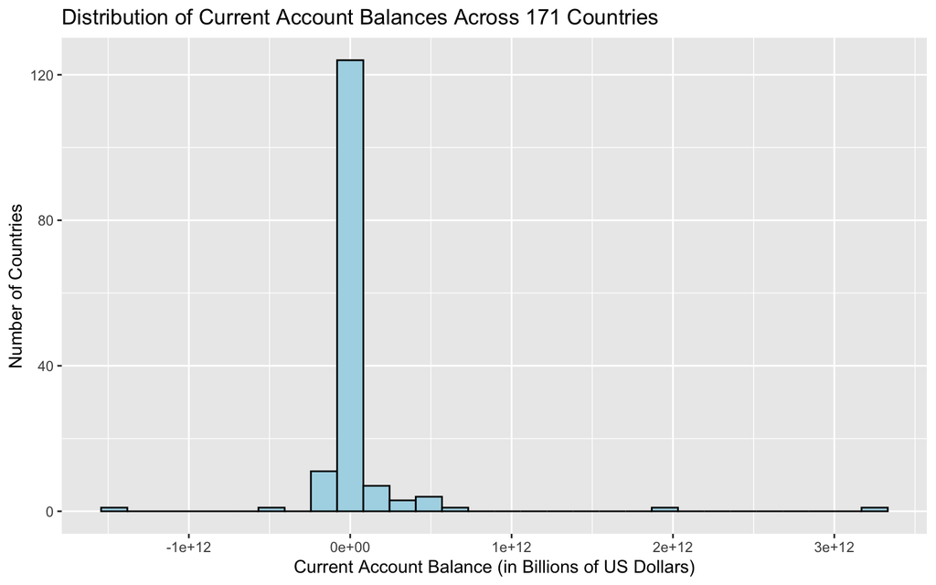

```r
library(ggplot2)
ggplot(result_df, aes(x = Current_Account_Balance)) +
  geom_histogram(fill = "lightblue", color = "black") +
  labs(title = "Distribution of Current Account Balances Across 171 Countries", x = "Current Account Balance (in Billions of US Dollars)" , y = "Number of Countries")
```

From the graph it is evident that more than 120 countries have their current account balances in the central tendency region

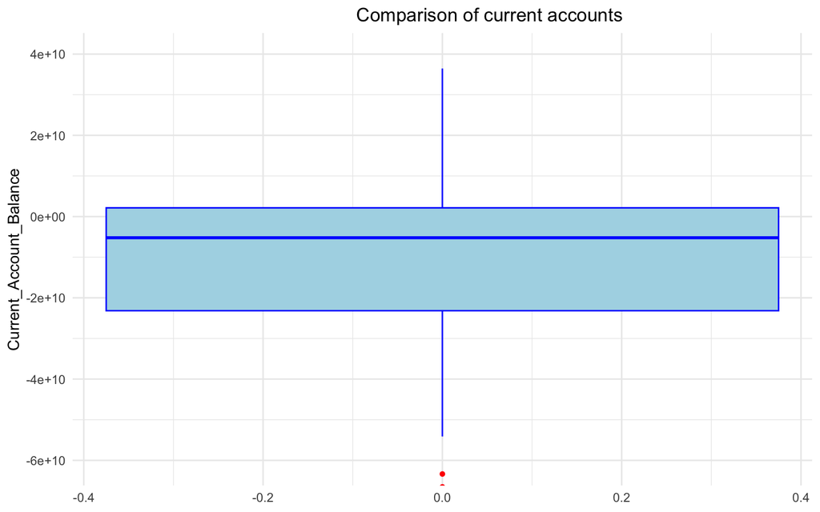

```r
Q1_Currentaccount <- quantile(result_df$Current_Account_Balance, 0.25, na.rm = TRUE)
Q3_Currentaccount <- quantile(result_df$Current_Account_Balance, 0.75, na.rm = TRUE)
IQR_currentaccount <- IQR(result_df$Current_Account_Balance, na.rm = TRUE)


ggplot(result_df, aes(y=Current_Account_Balance)) +
  geom_boxplot(fill="lightblue", color="blue", outlier.color="red", outlier.shape=16) +
  labs(title="Comparison of current accounts",
       y="Current_Account_Balance") +
  theme_minimal() +
  theme(plot.title=element_text(hjust=0.6)) +
  coord_cartesian(ylim=c(min(Q1_Currentaccount - 1.5*IQR_currentaccount),
                         max(Q3_Currentaccount + 1.5*IQR_currentaccount)))
```

*Distribution of Current Account Balances Across Countries*

```r
library(dplyr)
# Sort the original data frame by the "Total" column in descending order (highest to lowest)
df_sorted_descending <- result_df %>% arrange(desc(Trade_Balance_mean))

# Select the top 20 "Total" values
top_20 <- head(df_sorted_descending, 20)
```

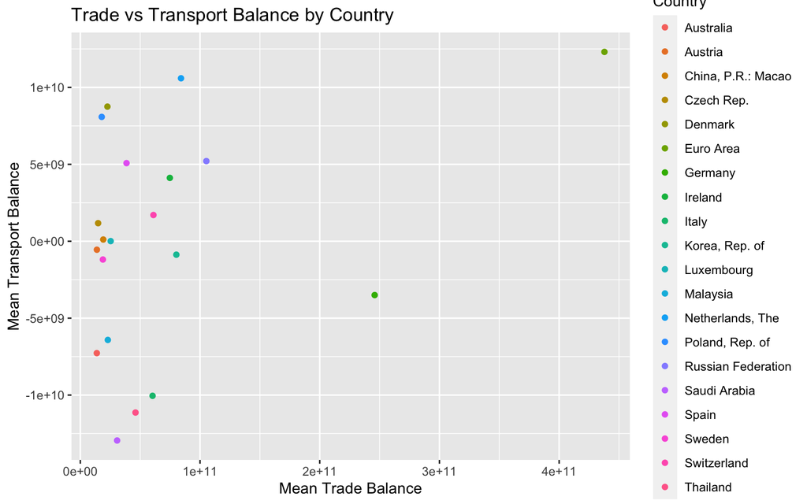

```r
library(ggplot2)
ggplot(top_20, aes(x = `Trade_Balance_mean`, y = `transport_Balance_mean`, color = Country)) +
  geom_point() +
  labs(title = "Trade vs Transport Balance by Country ", x = "Mean Trade Balance", y = "Mean Transport Balance")
```